# Thesis Question 1 & Question 2

Karen Abraham

12-09-2021

# Question 1: How has organized violence evolved over the last 30 years?

## Loading Data and Libraries

```r
#Clearing the environment
rm(list = ls())
options(warn=-1)

#Disable scientific notation
options(scipen = 999)

#Loading libraries (must be installed before where necessary)
library(readr)
library(dplyr)
```

```r
library(ggplot2)

#for q2 map
library(ggmap)
```

## UCDP Georeferenced Event Dataset (GED) Global version 21.1

Disaggregated dataset covering individual events of organized lethal violence.

- Pettersson, Therese, Shawn Davis, Amber Deniz, Garoun Engström, Nanar Hawach, Stina Högbladh, Margareta Sollenberg & Magnus Öberg (2021). Organized violence 1989-2020, with a special emphasis on Syria. Journal of Peace Research 58(4).
- Sundberg, Ralph and Erik Melander (2013) Introducing the UCDP Georeferenced Event Dataset. Journal of Peace Research 50(4).

```r
#Loading the dataset
ged211 <- read_csv("ged211.csv")
head(ged211)
```

| id | relid | year | active_year | code_status | type_of_violence | conflict_dset_id | conflict_new_id | conflict_name | dyad_dset_id | dyad_new_id | dyad_name | side_a_dset_id | side_a_new_id | side_a | side_b_dset_id | side_b_new_id | side_b | number_of_sources | source_article | source_office | source_date | source_headline | source_original | where_prec | where_coordinates | where_description | adm_1 | adm_2 | latitude | … |
| --- | --- | --- | --- | --- | --- | --- | --- | --- | --- | --- | --- | --- | --- | --- | --- | --- | --- | --- | --- | --- | --- | --- | --- | --- | --- | --- | --- | --- | --- | --- |
| 244657 | IRQ-2017-1-524-322 | 2017 | 1 | Clear | 1 | 259 | 259 | Iraq: Government | 524 | 524 | Government of Iraq - IS | 116 | 116 | Government of Iraq | 234 | 234 | IS | 3 | "Agence France Presse,2017-08-01,Attackers target Shiite mosque in Afghanistan's Herat";"Agence France Presse,2017-08-01,At least 20 killed in Shiite mosque attack in Afghanistan's Herat";"Pajhwok New… | Agence France Presse;Agence France Presse;Pajhwok News | 2017-08-01;2017-08-01;2017-07-31 | Attackers target Shiite mosque in Afghanistan's Herat;At least 20 killed in Shiite mosque attack in Afghanistan's Herat;Assailants among 6 killed in Iraq Embassy attack | IS, interior ministry, security source | 1 | Kabul city | Iraqi embassy in Kabul | Kabul province | Kabul district | 34.53109 | … |
| 132140 | AFG-1989-1-411-2 | 1989 | 1 | Clear | 1 | 333 | 333 | Afghanistan: Government | 724 | 724 | Government of Afghanistan - Jam'iyyat-i Islami-yi Afghanistan | 130 | 130 | Government of Afghanistan | 292 | 292 | Jam'iyyat-i Islami-yi Afghanistan | -1 | The Times 13 Jan 1989 "Missiles and tea breaks for rebels;Afghanistan | NA | NA | NA | Rebel source | 4 | Nangarhar province | Nangarhar province | Nangarhar province | NA | 34.33333 | … |
| 130364 | AFG-1989-1-411-37 | 1989 | 1 | Clear | 1 | 333 | 333 | Afghanistan: Government | 724 | 724 | Government of Afghanistan - Jam'iyyat-i Islami-yi Afghanistan | 130 | 130 | Government of Afghanistan | 292 | 292 | Jam'iyyat-i Islami-yi Afghanistan | -1 | R 18 Jan 1989 "KABUL REPORTS HUNDREDS OF REBEL CASUALTIES IN KUNDUZ PROVINCE. | NA | NA | NA | Kabul radio (monitored in Islamabad) | 4 | Kunduz province | Kunduz province | Kunduz province | NA | 36.75000 | … |
| 130359 | AFG-1989-1-411-4 | 1989 | 1 | Clear | 1 | 333 | 333 | Afghanistan: Government | 724 | 724 | Government of Afghanistan - Jam'iyyat-i Islami-yi Afghanistan | 130 | 130 | Government of Afghanistan | 292 | 292 | Jam'iyyat-i Islami-yi Afghanistan | -1 | Reuters 24 Jan 1989 "AFGHANS KILL NEARLY 400 REBELS, TASS SAYS." /The Washington Post 27 Jan 1989 "Rebels Send Food Convoy To Kabul;U.S. Orders Embassy Evacuated, Closed" /The Toronto Star 28 Jan 1989… | NA | NA | NA | Tass news agency /Western diplomats quoting witnesses /Rebel spokesman | 1 | Salang pass | Salang pass (on the main highway linking Kabul with the Soviet border) | Baghlan province | Khinjan district | 35.31583 | … |
| 133883 | AFG-1989-1-411-39 | 1989 | 1 | Clear | 1 | 333 | 333 | Afghanistan: Government | 724 | 724 | Government of Afghanistan - Jam'iyyat-i Islami-yi Afghanistan | 130 | 130 | Government of Afghanistan | 292 | 292 | Jam'iyyat-i Islami-yi Afghanistan | -1 | The Sunday Times 5 Feb 1989 "The Russians move out...;Withdrawal from Afghanistan | NA | NA | NA | Military spokesman | 1 | Kabul city | Kabul city | Kabul province | Kabul district | 34.53109 | … |
| 133874 | AFG-1989-1-411-6 | 1989 | 1 | Clear | 1 | 333 | 333 | Afghanistan: Government | 724 | 724 | Government of Afghanistan - Jam'iyyat-i Islami-yi Afghanistan | 130 | 130 | Government of Afghanistan | 292 | 292 | Jam'iyyat-i Islami-yi Afghanistan | -1 | St. Louis Post-Dispatch 1 Feb 1989 "JET CARRYING U.S. ENVOYS NEARLY HITS SOVIET PLANE | NA | NA | NA | Rebel spokesman | 2 | Salang tunnel | Salang tunnel (near, villages near the main Soviet withdrawal route, Salang tunnel) | Baghlan province | Khinjan district | 35.31603 | … |

```r
#Dimensions of the dataset
dim(ged211)
```

```
## [1] 261864     49
```

```r
summary(ged211)
```

```
##        id            relid                year       active_year
##  Min.   :     4   Length:261864      Min.   :1989   Min.   :0.000
##  1st Qu.:104388   Class :character   1st Qu.:2004   1st Qu.:1.000
##  Median :211886   Mode  :character   Median :2013   Median :1.000
##  Mean   :204135                      Mean   :2010   Mean   :0.966
##  3rd Qu.:299287                      3rd Qu.:2016   3rd Qu.:1.000
##  Max.   :390297                      Max.   :2020   Max.   :1.000
##
##  code_status        type_of_violence conflict_dset_id conflict_new_id
##  Length:261864      Min.   :1.000    Min.   :    6    Min.   :  205
##  Class :character   1st Qu.:1.000    1st Qu.:  299    1st Qu.:  299
##  Mode  :character   Median :1.000    Median :  333    Median :  333
##                     Mean   :1.417    Mean   : 2202    Mean   : 2212
##                     3rd Qu.:2.000    3rd Qu.:  401    3rd Qu.:  506
##                     Max.   :3.000    Max.   :16692    Max.   :15263
##
##  conflict_name       dyad_dset_id    dyad_new_id     dyad_name
##  Length:261864      Min.   :    6   Min.   :  406   Length:261864
##  Class :character   1st Qu.:  714   1st Qu.:  735   Class :character
##  Mode  :character   Median :  830   Median :  973   Mode  :character
##                     Mean   : 5385   Mean   : 5569
##                     3rd Qu.:11973   3rd Qu.:11973
##                     Max.   :16692   Max.   :16692
##
##  side_a_dset_id   side_a_new_id       side_a          side_b_dset_id
##  Min.   :   3.0   Min.   :   3.0   Length:261864      Min.   :   3
##  1st Qu.: 118.0   1st Qu.: 118.0   Class :character   1st Qu.: 303
##  Median : 121.0   Median : 121.0   Mode  :character   Median : 775
##  Mean   : 387.7   Mean   : 387.7                      Mean   :3220
##  3rd Qu.: 146.0   3rd Qu.: 146.0                      3rd Qu.:4456
##  Max.   :7984.0   Max.   :7984.0                      Max.   :9999
##
##  side_b_new_id     side_b          number_of_sources  source_article
##  Min.   :   1   Length:261864      Min.   : -1.0000   Length:261864
##  1st Qu.: 234   Class :character   1st Qu.: -1.0000   Class :character
##  Median : 341   Mode  :character   Median :  1.0000   Mode  :character
##  Mean   :1689                      Mean   :  0.4581
##  3rd Qu.:4456                      3rd Qu.:  1.0000
##  Max.   :8006                      Max.   :363.0000
##
```

[output cut: 49 more lines]

```
##  Min.   :    0.00   Min.   :    0.00   Min.   :    0.00   Min.   :    0.00
##  1st Qu.:    0.00   1st Qu.:    0.00   1st Qu.:    1.00   1st Qu.:    1.00
##  Median :    0.00   Median :    0.00   Median :    2.00   Median :    2.00
##  Mean   :    3.99   Mean   :    1.92   Mean   :   10.28   Mean   :   15.98
##  3rd Qu.:    1.00   3rd Qu.:    0.00   3rd Qu.:    5.00   3rd Qu.:    6.00
##  Max.   :40000.00   Max.   :48183.00   Max.   :48183.00   Max.   :75000.00
##
##       low               gwnoa        gwnob
##  Min.   :    0.00   Min.   :  2     Mode:logical
##  1st Qu.:    1.00   1st Qu.:640     NA's:261864
##  Median :    2.00   Median :652
##  Mean   :    8.71   Mean   :628
##  3rd Qu.:    5.00   3rd Qu.:700
##  Max.   :48183.00   Max.   :910
##                     NA's   :54486
```

## Aggregate Statistics

### Number of deaths

```r
#What is the mean death toll for an instance of violence
print(cat(c("Mean: ", round(mean(ged211$best),2), "Median: ", round(median(ged211$best),2) ,"Standard Deviation:", round(sd(ged211$best),2), "\n")))
```

```
## Mean:  10.28 Median:  2 Standard Deviation: 222.56
## NULL
```

### Standard deviation vs estimation error

```r
#The standard deviation gives us the variation in the number of deaths for all instances, but not a measure of accuracy
#Let's take the differences between the highest estimate and lowest estimate for each instance and average the result
mean(ged211$high - ged211$low)
```

```
## [1] 7.272191
```

```r
median(ged211$high - ged211$low)
```

```
## [1] 0
```

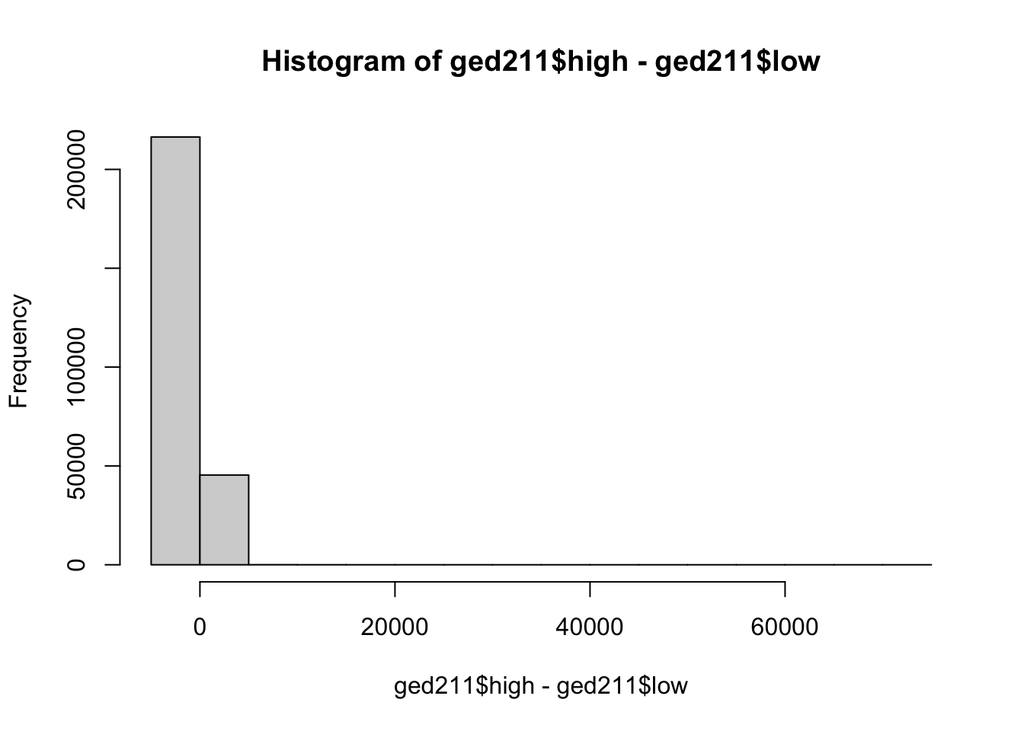

```r
hist(ged211$high - ged211$low)
```

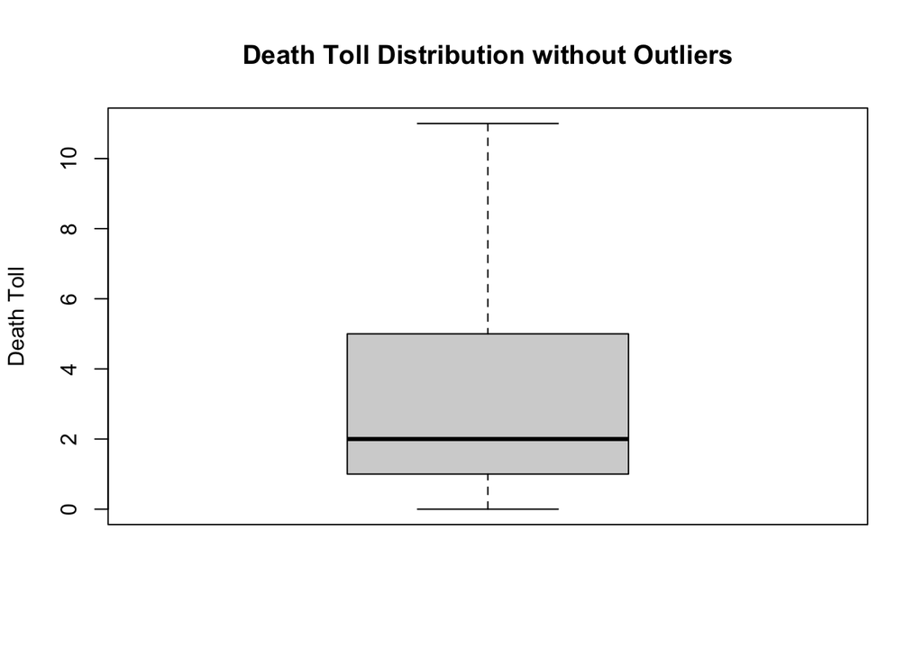

```r
#What is the death toll distribution for an instances of violence
boxplot(ged211$best,outline=FALSE, main="Death Toll Distribution without Outliers", ylab="Death Toll")
```

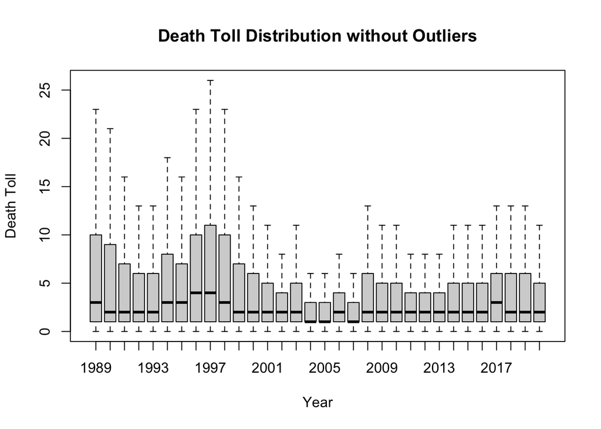

```r
#What is the death toll distribution for an instances of violence over time
boxplot(best~year, data=ged211,outline=FALSE, main="Death Toll Distribution without Outliers", ylab="Death Toll",xlab="Year")
```

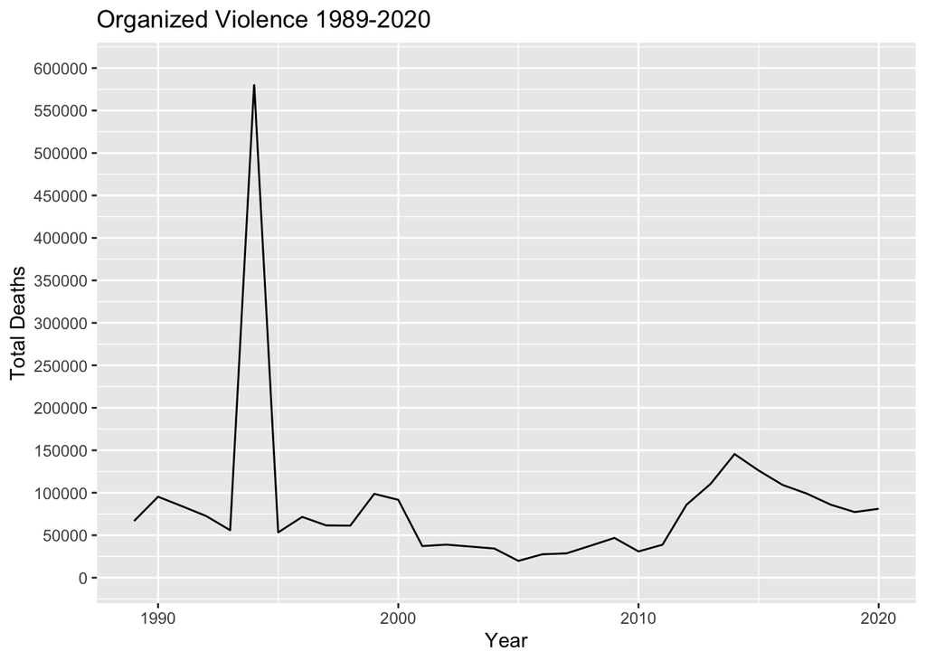

```r
#Sum of deaths by year
ttl <- ged211%>%
  dplyr::group_by(year) %>%
  dplyr::summarize(total = sum(best))

ttl %>%
  ggplot( aes(x=year, y=total)) +
  geom_line() +
  ggtitle("Organized Violence 1989-2020") +
  xlab("Year") +
  ylab("Total Deaths")+
  scale_y_continuous(breaks=c(0,50000,100000,150000,200000,250000,300000,350000,400000,450000,500000,550000,600000),limits=c(0, 600000)) #Axes labels manually added
```

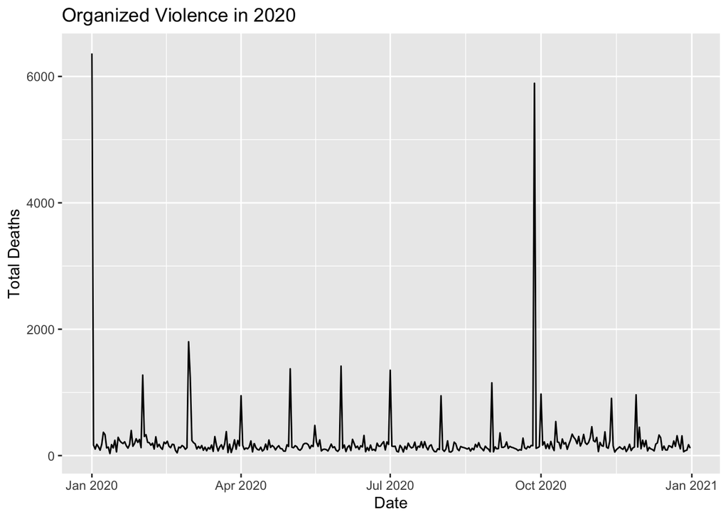

```r
#sum of deaths by date from Jan 2020
ttl_2020 <- subset(ged211, year>=2020)

ttl_2020 <- ttl_2020 %>%
  dplyr::group_by(date_start) %>%
  dplyr::summarize(total = sum(best))

ttl_2020 %>%
  ggplot( aes(x=date_start, y=total)) +
  geom_line() +
  ggtitle("Organized Violence in 2020") +
  xlab("Date") +
  ylab("Total Deaths")
```

## Type of violence

1. State-Based Armed Conflict: Violence between two organized actors of which at least one is the government of a state
2. Non-State Conflict: Violence between actors of which neither party is the government of a state
3. One-Sided Violence: Unarmed civilians perpetrated by organized non-state groups or governments

```r
#make type of violence a factor
ged211$type_of_violence <- as.factor(ged211$type_of_violence)

#group
ttl <- ged211%>%
  dplyr::group_by(type_of_violence,year) %>%
  dplyr::summarize(total = sum(best))
```

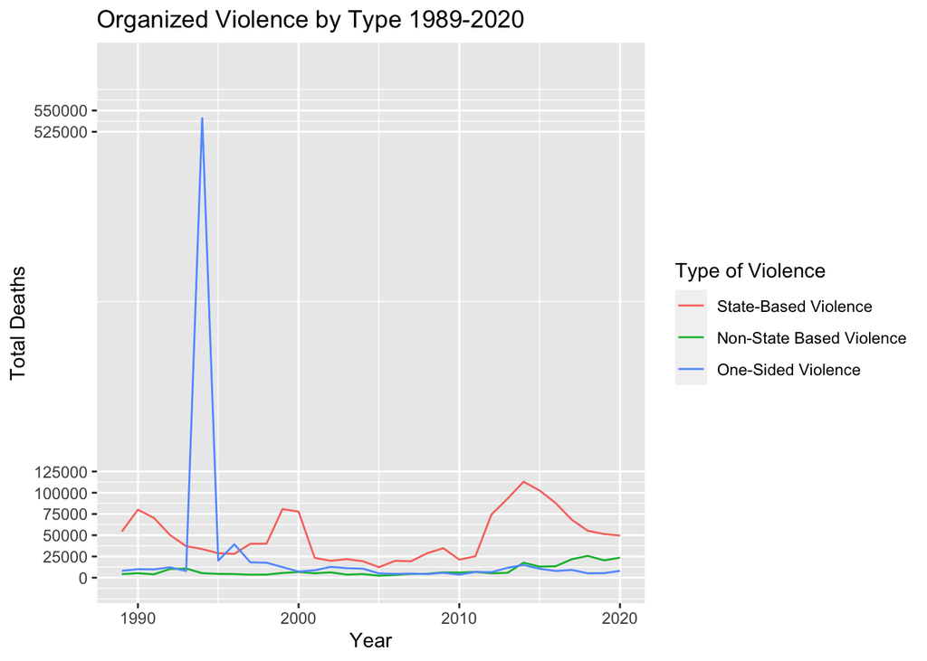

```r
#plot
ttl %>%
  ggplot( aes(x=year, y=total, col=type_of_violence)) +
  geom_line() +
  ggtitle("Organized Violence by Type 1989-2020") +
  xlab("Year")+
  ylab("Total Deaths")+
  scale_y_continuous(breaks=c(0,25000,50000,75000,100000,125000,5500000,525000,550000),limits=c(0, 600000)) +
  scale_color_discrete(name = "Type of Violence",labels = c("State-Based Violence", "Non-State Based Violence", "One-Sided Violence"))
```

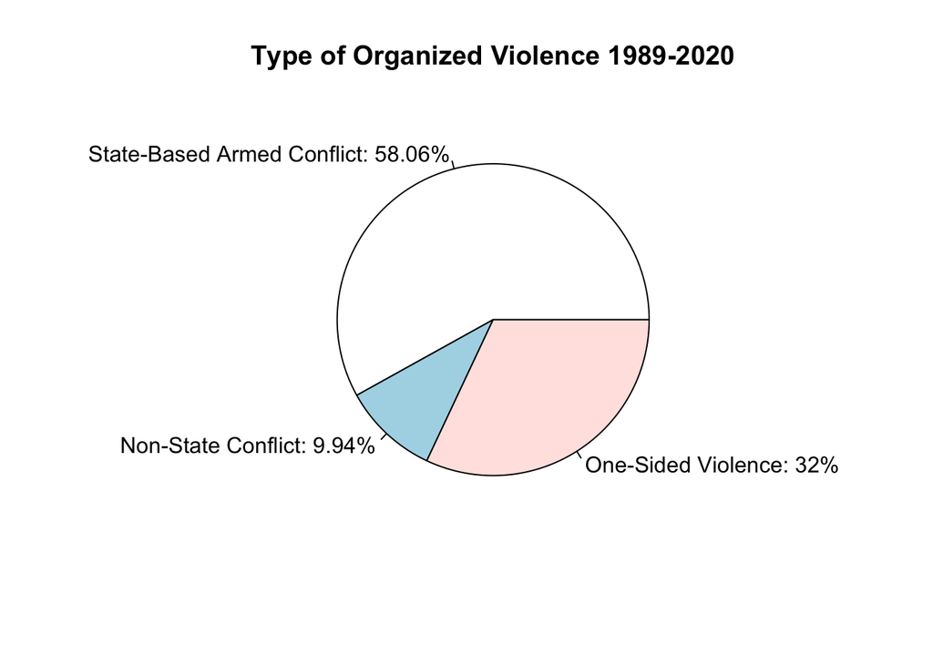

```r
type_of_violence <- ged211%>%
  dplyr::group_by(type_of_violence) %>%
  dplyr::summarize(total = sum(best))

pie_labels <- paste0(c("State-Based Armed Conflict","Non-State Conflict","One-Sided Violence"), ": ", round(100 * type_of_violence$total / sum(type_of_violence$total), 2), "%")

pie(type_of_violence$total,pie_labels, main="Type of Organized Violence 1989-2020")
```

Since we see in the line plot that the distribution of type of violence changes, let’s look at the make up of violence after 2018 (both 2019 and 2020 together) to assess the current situation

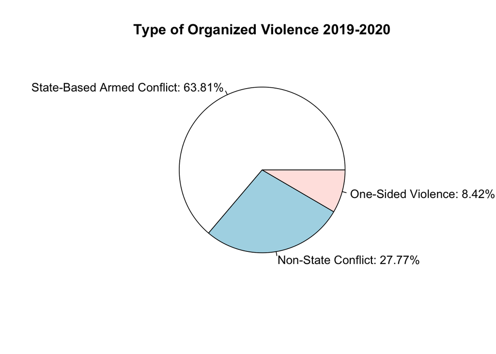

```r
type_of_violence_2019 <- subset(ged211, year >= 2019)

type_of_violence_2019 <- type_of_violence_2019%>%
  dplyr::group_by(type_of_violence) %>%
  dplyr::summarize(total = sum(best))

pie_labels_2019 <- paste0(c("State-Based Armed Conflict","Non-State Conflict","One-Sided Violence"), ": ", round(100 * type_of_violence_2019$total / sum(type_of_violence_2019$total), 2), "%")

pie(type_of_violence_2019$total,pie_labels_2019, main="Type of Organized Violence 2019-2020")
```